# The Kalman Filter

10 Oct 2016

## Smoothing again

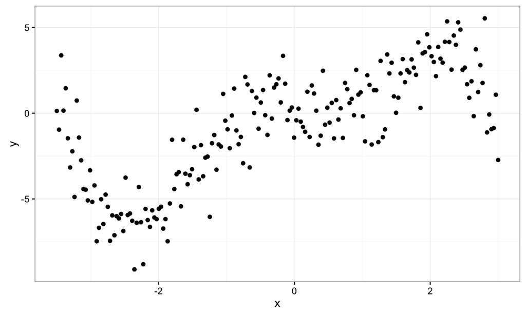

## Gaussian processes

Suppose that \(X = X_{1:n} \sim \mathcal{N}(\xi_x, \Sigma_{x})\) with \[\mathrm{cov}(X_i, X_j) = K(t_i - t_j)\] for a kernel function \(K\).

With the *observation equation* \(Y_i = X_i + \delta_i\) for \(\delta = \delta_{1:n} \sim \mathcal{N}(0, \Omega)\) and \(\delta \perp \! \! \perp X\) we get \[(X, Y) \sim \mathcal{N}\left(\left(\begin{array}{c} \xi_x \\ \xi_x \end{array}\right), \left(\begin{array}{cc} \Sigma_x & \Sigma_x \\ \Sigma_x & \Sigma_x + \Omega \end{array} \right) \right).\]

Hence \[E(X \mid Y) = \xi_x + \Sigma_x (\Sigma_x + \Omega)^{-1} (Y - \xi_x).\]

## Gaussian processes and smoothing

Assuming that \(\xi_x = 0\) the conditional expectation is a linear smoother with smoother matrix \[S = \Sigma_x (\Sigma_x + \Omega)^{-1}.\]

This is also true if \(\Sigma_x (\Sigma_x + \Omega)^{-1} \xi_x = \xi_x\). If this identity holds approximately, we can argue that for computing \(E(X \mid Y)\) we don't need to know \(\xi_x\).

If the observation variance is \(\Omega = \sigma^2 I\) then the smoother matrix is \[\Sigma_x (\Sigma_x + \sigma^2 I)^{-1} = (I + \sigma^2 \Sigma_x^{-1})^{-1}.\]

## The Kalman filter and smoother

Suppose that \(|\alpha| < 1\), \(X_1 = \epsilon_1 / \sqrt{1 - \alpha^2}\) and \[X_i = \alpha X_{i-1} + \epsilon_i\] for \(i = 2, \ldots, n\) with \(\epsilon = \epsilon_{1:n} \sim \mathcal{N}(0, I)\).

Then the computation of \(E(X_n \mid Y)\) is a filtering problem for a hidden Markov model that fits into the sequential Monte Carlo framework.

But we also have \(\mathrm{cov}(X_i, X_j) = \alpha^{|i-j|} / (1 - \alpha^2)\), thus we can find \(\Sigma_x\) and compute \[E(X_n \mid Y) = ((I + \sigma^2 \Sigma_x^{-1})^{-1} Y)_n\]

## Examples, \(\alpha = 0.3\), \(\sigma^2 = 2\),

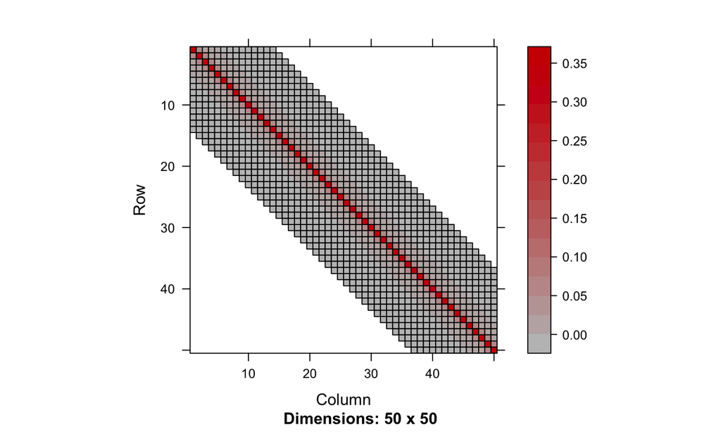

## Examples, \(\alpha = 0.3\), \(\sigma^2 = 20\),

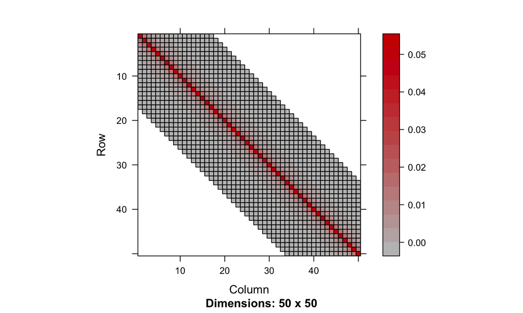

## Examples, \(\alpha = 0.9\), \(\sigma^2 = 2\),

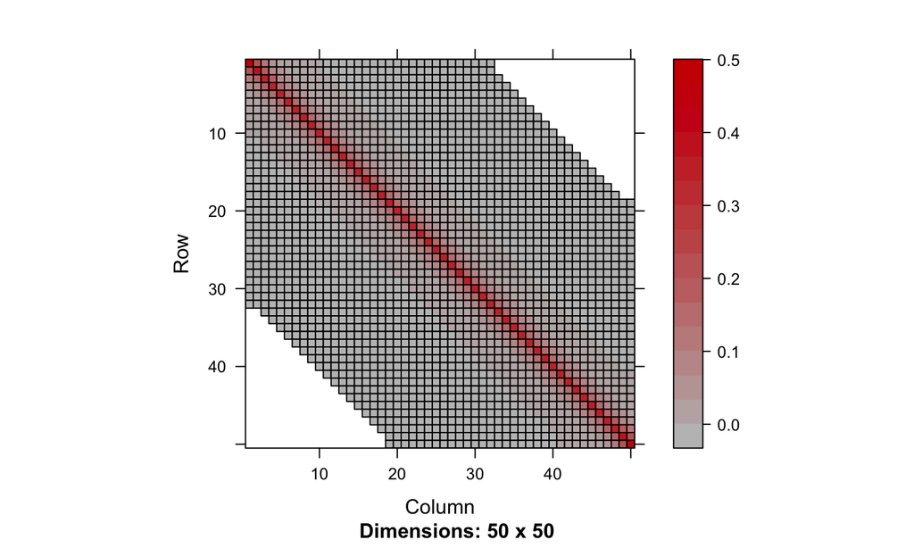

## Examples, \(\alpha = 0.9\), \(\sigma^2 = 20\),

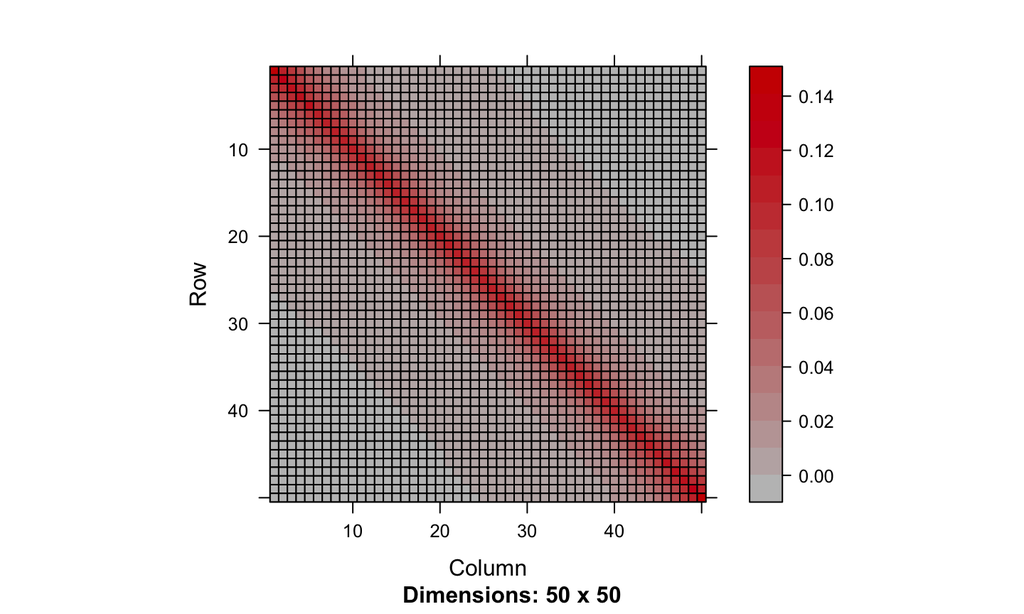

## Examples, \(n = 50, S[25, ]\)

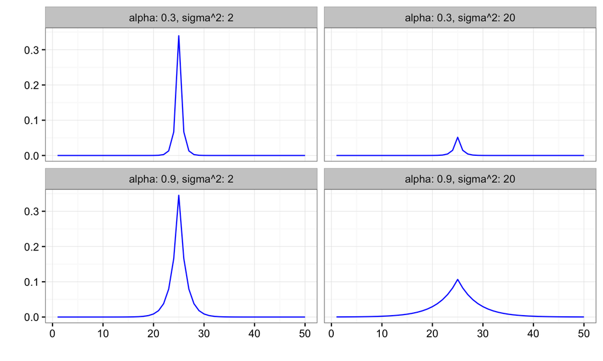

## The main point

Observe that \[\Sigma_x^{-1} = \left( \begin{array}{cccccc} 1 & -\alpha & 0 & \ldots & 0 & 0 \\ -\alpha & 1 + \alpha^2 & -\alpha & \ldots & 0 & 0 \\ 0 & -\alpha & 1 + \alpha^2 & \ldots & 0 & 0 \\ \vdots & \vdots & \vdots & \ddots & \vdots & \vdots \\ 0 & 0 & 0 & \ldots & 1 + \alpha^2 & -\alpha \\ 0 & 0 & 0 & \ldots & -\alpha & 1 \\ \end{array}\right).\]

## Derivation

This can be derived from observing that \(\epsilon = A X\) where

\[A = \left( \begin{array}{cccccc} \sqrt{1 - \alpha^2} & 0 & 0 & \ldots & 0 & 0 \\ -\alpha & 1 & 0 & \ldots & 0 & 0 \\ 0 & -\alpha & 1 & \ldots & 0 & 0 \\ \vdots & \vdots & \vdots & \ddots & \vdots & \vdots \\ 0 & 0 & 0 & \ldots & 1 & 0 \\ 0 & 0 & 0 & \ldots & -\alpha & 1 \\ \end{array}\right),\]

which follows from the identity \(\epsilon_i = X_i - \alpha X_{i-1}\). This gives \(I = V(\epsilon) = A \Sigma_x A^T\), hence \[\Sigma_x^{-1} = (A^{-1}(A^T)^{-1})^{-1} = A^T A.\]

## The main point

Hence \[I + \sigma^2 \Sigma_x^{-1} = \left( \begin{array}{cccccc} \gamma_0 & \rho & 0 & \ldots & 0 & 0 \\ \rho & \gamma & \rho & \ldots & 0 & 0 \\ 0 & \rho & \gamma & \ldots & 0 & 0 \\ \vdots & \vdots & \vdots & \ddots & \vdots & \vdots \\ 0 & 0 & 0 & \ldots & \gamma & \rho \\ 0 & 0 & 0 & \ldots & \rho & \gamma_0 \\ \end{array}\right)\]

with \(\gamma_0 = 1 + \sigma^2\), \(\gamma = 1 + \sigma^2 (1 + \alpha^2)\) and \(\rho = -\sigma^2 \alpha\) is a *tridiagonal matrix.*

## Solving an equation

The equation

\[\left( \begin{array}{cccccc} \gamma_0 & \rho & 0 & \ldots & 0 & 0 \\ \rho & \gamma & \rho & \ldots & 0 & 0 \\ 0 & \rho & \gamma & \ldots & 0 & 0 \\ \vdots & \vdots & \vdots & \ddots & \vdots & \vdots \\ 0 & 0 & 0 & \ldots & \gamma & \rho \\ 0 & 0 & 0 & \ldots & \rho & \gamma_0 \\ \end{array}\right) \left( \begin{array}{c} x_1 \\ x_2 \\ x_3 \\ \vdots \\ x_{n-1} \\ x_n \end{array}\right) = \left(\begin{array}{c} y_1 \\ y_2 \\ y_3 \\ \vdots \\ y_{n-1} \\ y_n \end{array}\right)\]

can be solved by a forward and backward sweep.

## Forward sweep

Set \(\rho_1' = \rho / \gamma_0\) and \(y_1' = y_1 / \gamma_0\),

then recursively \[\rho_i' = \frac{\rho}{\gamma - \rho \rho_{i-1}'} \quad \text{and} \quad y_i' = \frac{y_i - \rho y_{i-1}'}{\gamma - \rho \rho_{i-1}'}\] for \(i = 2, \ldots, n-1\)

and finally \[y_n' = \frac{y_n - \rho y_{n-1}'}{\gamma_0 - \rho \rho_{n-1}'}.\]

## Forward sweep result

By the forward sweep the equation is transformed to

\[\left( \begin{array}{cccccc} 1 & \rho_1' & 0 & \ldots & 0 & 0 \\ 0 & 1 & \rho_2' & \ldots & 0 & 0 \\ 0 & 0 & 1 & \ldots & 0 & 0 \\ \vdots & \vdots & \vdots & \ddots & \vdots & \vdots \\ 0 & 0 & 0 & \ldots & 1 & \rho_{n-1}' \\ 0 & 0 & 0 & \ldots & 0 & 1 \\ \end{array}\right) \left( \begin{array}{c} x_1 \\ x_2 \\ x_3 \\ \vdots \\ x_{n-1} \\ x_n \end{array}\right) = \left(\begin{array}{c} y_1' \\ y_2' \\ y_3' \\ \vdots \\ y_{n-1}' \\ y_n' \end{array}\right),\]

which is then solved by backsubstitution from below; \(x_n = y_n'\) and \[x_{i} = y_i' - \rho_{i}' x_{i+1}, \quad i = n-1, \ldots, 1.\]

## Implementation

```r
cppFunction(
  'NumericVector KalmanSmooth(NumericVector y, double alpha, double sigmasq) {
  double tmp, gamma0 = 1 + sigmasq, rho = - sigmasq * alpha;
  double gamma = 1 + sigmasq * (1 + alpha * alpha);
  int n = y.size();
  NumericVector x(n), rhop(n - 1);
  rhop[0] = rho / gamma0;
  x[0] = y[0] / gamma0;
  for(int i = 1; i < n - 1; ++i) { /* Forward sweep */
    tmp = (gamma - rho * rhop[i - 1]);
    rhop[i] = rho / tmp;
    x[i] = (y[i] - rho * x[i - 1]) / tmp;
  }
  x[n - 1] = (y[n - 1] - rho * x[n - 2]) / (gamma0 - rho * rhop[n - 2]);
  for(int i = n - 2; i >= 0; --i) { /* Backsubstitution */
    x[i] = x[i] - rhop[i] * x[i + 1];
  }
  return x;
  }')
```

## Result, \(\alpha = 0.95\), \(\sigma^2 = 10\)

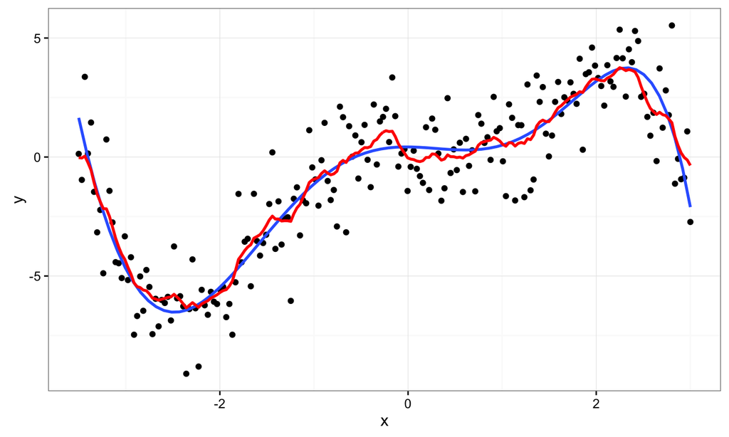

## Comparing results

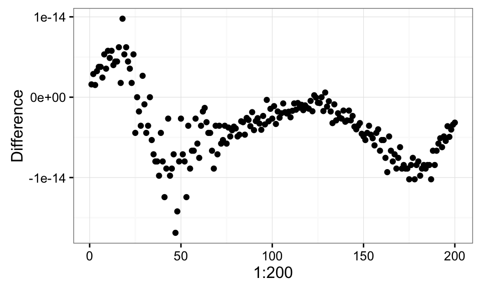

```r
n <- 200; alpha <- 0.95; sigmasq <- 10
Sigma <- outer(1:n, 1:n,
               function(i, j) alpha^(abs(i - j))) / (1 - alpha^2)
Smooth <- Sigma %*% solve(Sigma + sigmasq * diag(n))
qplot(1:200, Smooth %*% bivar$y - ySmooth) +
  ylab("Difference")
```

## The Kalman smoother

Note that the forward sweep only computes \(x_n = E(X_n \mid Y)\), and thus solves the filtration problem. From this, the backsubstitution solves the smoothing problem of computing \(E(X \mid Y)\).

The Gaussian process used here (the AR(1)-process) is not very smooth and nor is the smooth of the data. This is related to the kernel function \(K(s) = \alpha^{|s|}\) being non-differentiable in 0.

Many smoothers are equivalent to a Gaussian process smoother with an appropriate choice of kernel. Not all have a simple inverse covariance matrix and a Kalman filter algorithm.

## The Kalman filter only (forward sweep)

```r
cppFunction(
  'NumericVector KalmanFilt(NumericVector y, double alpha, double sigmasq) {
  double tmp, gamma0 = 1 + sigmasq, rho = - sigmasq * alpha, yp;
  double gamma = 1 + sigmasq * (1 + alpha * alpha);
  int n = y.size();
  NumericVector x(n), rhop(n);
  rhop[0] = rho / gamma0;
  yp = y[0] / gamma0;
  x[0] = y[0] / (1 + sigmasq * (1 - alpha * alpha));
  for(int i = 1; i < n; ++i) {
    tmp = (gamma - rho * rhop[i - 1]);
    rhop[i] = rho / tmp;
    /* Note differences when compared to smoother */
    x[i] = (y[i] - rho * yp) / (gamma0 - rho * rhop[i - 1]);
    yp = (y[i] - rho * yp) / tmp;
  }
  return x;
  }')
```

## Result, \(\alpha = 0.95\), \(\sigma^2 = 10\)

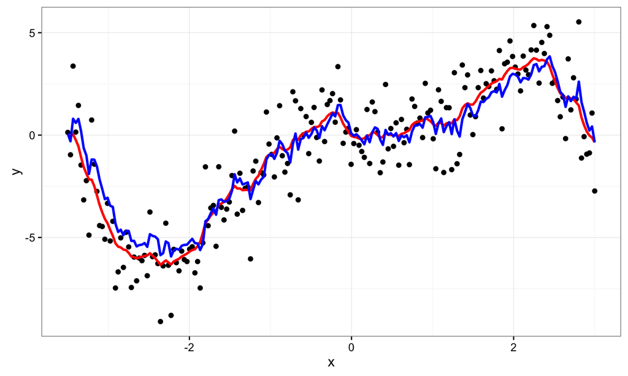

## Sequential MC for the AR(1)-process

Recall the update equation \[X_{t} = \alpha X_{t-1} + \epsilon_t.\] and the observation equation \[Y_t = X_t + \delta_t.\]

## Simulating a sample path

```r
simAR <- function(t, alpha) {
  x <- numeric(t)
  e <- rnorm(t, 0, 1)
  x[1] <- e[1] / sqrt(1 - alpha^2)
  for(s in seq_len(t)[-1]) {
    x[s] <- alpha * x[s - 1] + e[s]
  }
  x
}
```

## Simulating a sample path

We first generate a realization from the process with \(\alpha = 0.9\) and observation variance \(\sigma^2 = 10\).

```r
t <- 100; alpha <- 0.9; sigma <- sqrt(10)
x <- simAR(t, alpha)
y <- rnorm(t, x, sigma)
```

## The simulated sample path

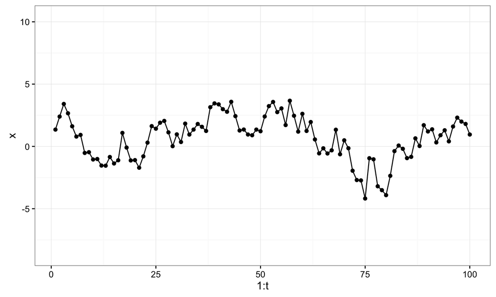

## Sample path with observations

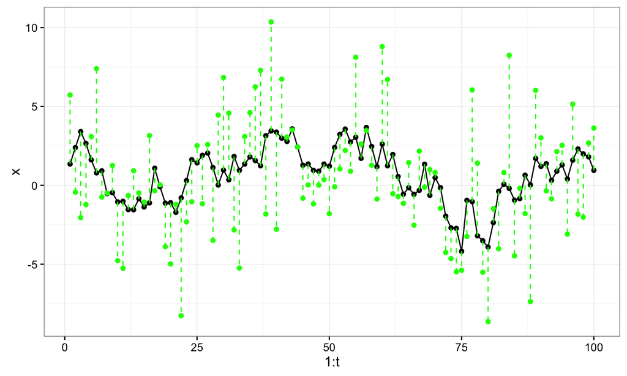

## … and observations only

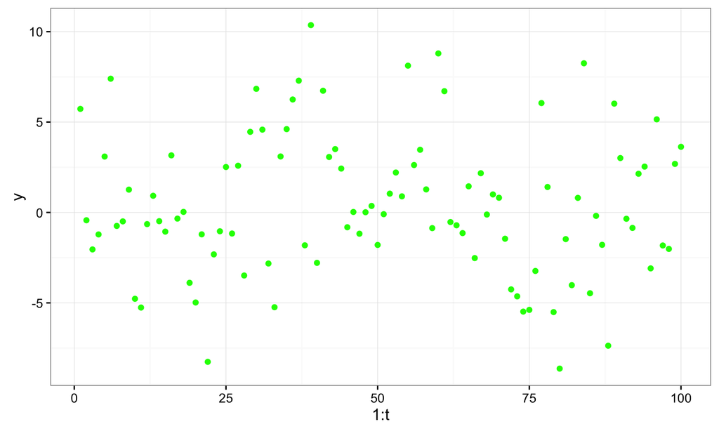

## Using the Kalman smoother

We can use the implemented Kalman smoother and Kalman filter to compute the best prediction of the unobserved process.

```r
xSmooth <- KalmanSmooth(y, alpha, sigma^2)
xFilt <- KalmanFilt(y, alpha, sigma^2)
```

## Using the Kalman smoother

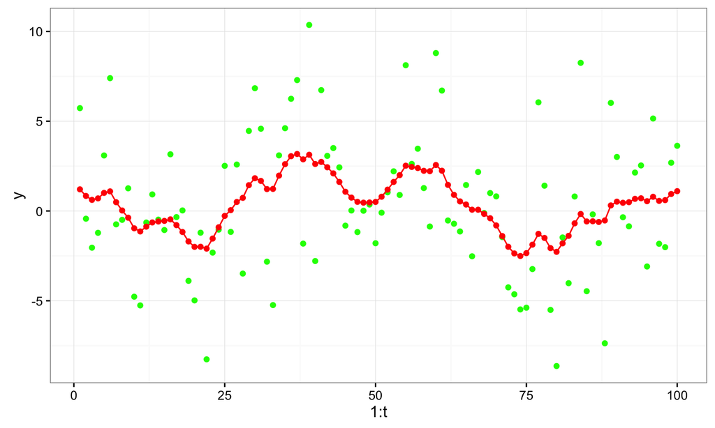

## Using the Kalman filter only

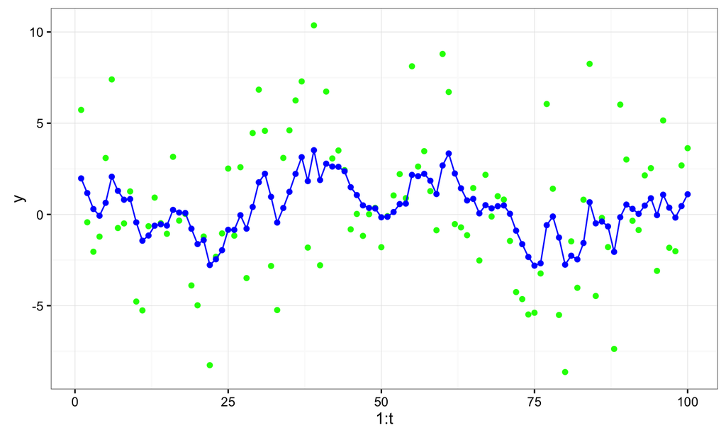

## Kalman filter and \(X\)-process

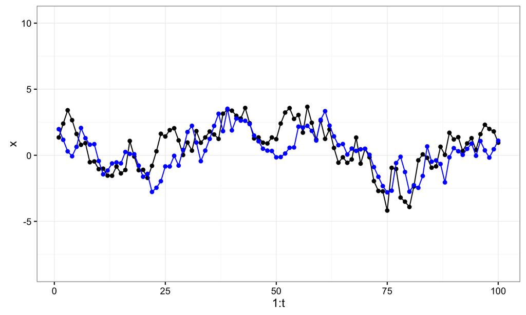

## Bootstrap filter

```r
bootAR <- function(y, n, alpha, sigma){
  t <- length(y)
  x <- xre <- matrix(0, n, t)
  u <- matrix(0, n, t)
  e <- matrix(rnorm(n * t, 0, 1), n, t)
  x[, 1] <- e[, 1] / sqrt(1 - alpha^2)
  for(s in seq_len(t - 1)) {
    u[, s] <- dnorm(y[s], x[, s], sigma)
    resamp <- sample(n, n, replace = TRUE, prob = u[, s])
    x[, s + 1] <- alpha * x[resamp, s] + e[, s + 1]
  }
  u[, t] <- dnorm(y[t], x[, t], sigma)
  list(x = x, u = u)
}
```

## Filtering with 10 particles

```r
set.seed(10102016)
n <- 10
```

```r
bootFilt <- bootAR(y, n, alpha, sigma)
xBootFilt <- colSums(bootFilt$x * bootFilt$u) / colSums(bootFilt$u)
```

## Filtering with 10 particles

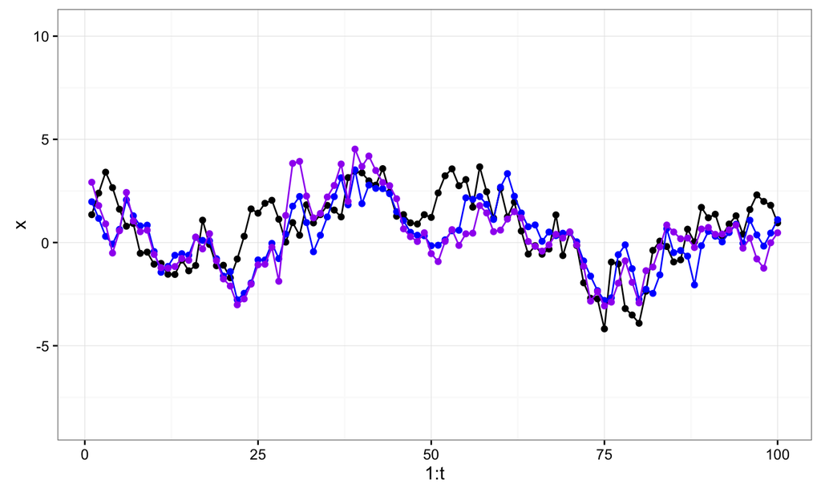

## … with 100 particles …

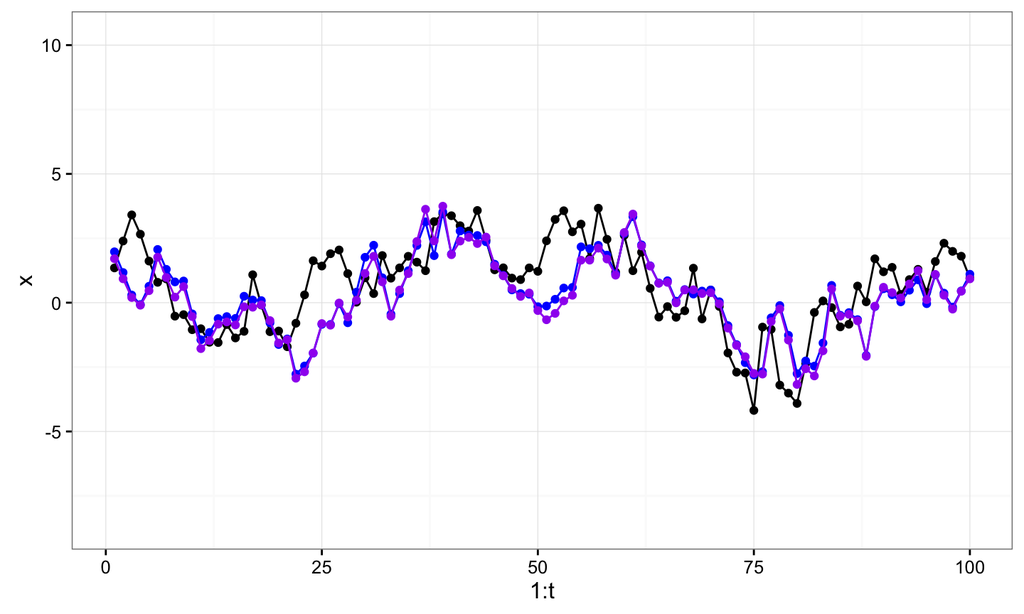

## … and with 1000 particles

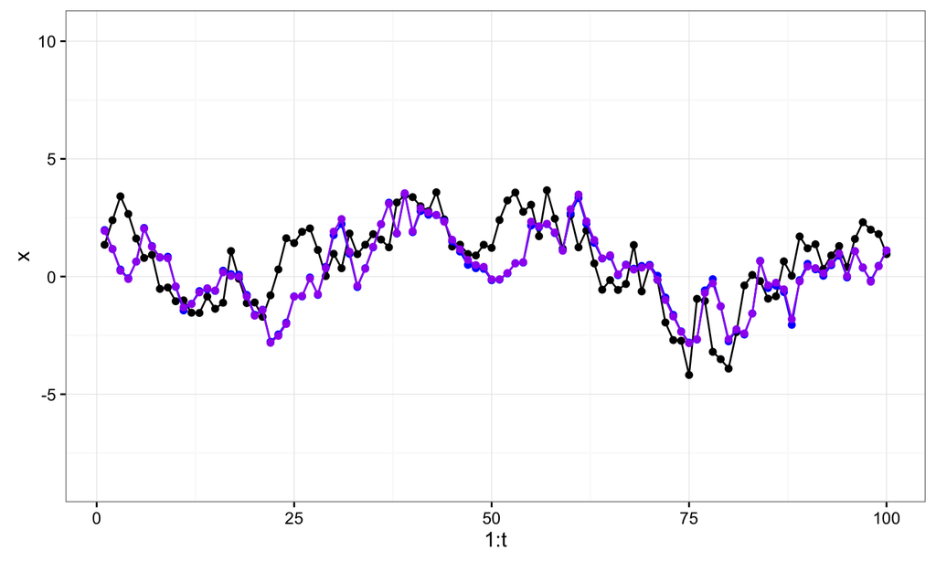

## Rcpp implementation

```r
sourceCpp("SMC.cpp")
```

The source file, SMC.cpp, contains the C++ code.

```r
set.seed(10102016)
bootFilt <- bootARfast(y, n, alpha, sigma)
xBootFilt2 <- colSums(bootFilt$x * bootFilt$u) / colSums(bootFilt$u)
```

## Rcpp implementation

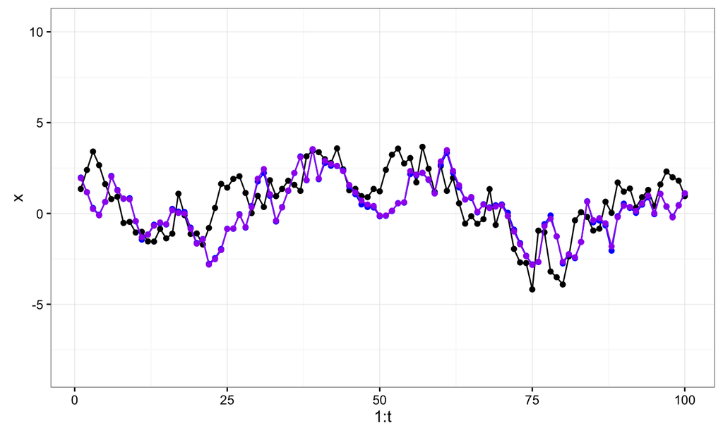

## Rcpp comparison

The two implementations do, in fact, compute the same if they are started as above with the same seed.

```r
max(abs(xBootFilt2 - xBootFilt))
```

```
[1] 8.881784e-16
```

Conditional expectations from the bootstrap filter converges for \(n \to \infty\) toward the Kalman filter. The bootstrap filter is a general algorithm whereas the Kalman filter is specific to Gaussian and linear processes.

## Benchmarking

```r
tmp <- microbenchmark(bootAR(y, 1000, alpha, sigma),
                      bootARfast(y, 1000, alpha, sigma),
                      KalmanFilt(y, alpha, sigma^2))
tmp
```

```
Unit: microseconds
       expr     min      lq  mean median    uq    max neval cld
     bootAR 21360.7 23214.7 34041  24374 25780 120381   100   c
 bootARfast 13242.1 14022.3 20275  15007 15900 109799   100  b
 KalmanFilt     4.3     6.2    14     15    19     30   100 a
```

The Kalman filter is blazingly fast, while the Rcpp version of the bootstrap filter is not even a factor two faster than the pure R implementation.

## Summary

- The Kalman filter and Kalman smoother are ideal for implementation using Rcpp. Though no R implementation was made for comparison, it is likely to be somewhat slower.
- The bootstrap filter could be conveniently implemented in R. The loop is over the observations, while all particles are handled in a vectorized way.
- The Rcpp implementation is longer, and `sample` is not directly available. Instead, sampling is performed using a function from RcppArmadillo (another R package).
- I suspect the sample function used via Rcpp is a bottleneck. Sampling from a very large number of items is, in fact, not entirely trivial to do fastly.